# Gradient Boosting Trees

Big Data and Machine Learning for Applied Economics - Econ 4676

Eduard-Martínez y Lucas Antonio II

Universidad de los Andes

# Introducción

Recordemos que en el modelo de Random Forest se utiliza la técnica de *bagging* en donde se hacen múltiples copias de la base de entrenamiento utilizando *bootstrap*. Allí se ajusta un árbol de decisión **independiente a cada copia** y al final se combinan todos los árboles para crear un único modelo predictivo.

El *boosting* funciona de forma similar, sin embargo la principal diferencia es que los árboles se entrenan de forma **secuencial**: cada árbol se entrena utilizando la información de los árboles entrenados anteriormente. El *boosting* no implica un muestreo bootstrap, sino que cada árbol se ajusta a una versión modificada del conjunto de datos original.

El algoritmo de *Boosting* se explica a continuación:

1. **Inicialización:** Defina $f(x)=0$ y $r_i=y_i$ para todas las observaciones $i$ de la base de entrenamiento.
2. **Aprendizaje:** Para $m=1,2,\cdots,M$ repita:
   - Entrene el árbol $\hat{f^m}$ con $d$ paticiones ($d+1$ nodos terminales) sobre el conjunto de entrenamiento $(X,r)$.
   - Actualice $\hat{f}$ añadiendole una versión regularizada del árbol entrenado en la iteración actual $m$:
     $$\hat{f}(x)\leftarrow \hat{f}(x) + \lambda \times
     \hat{f^m}(x)$$
   - Actualizar los residuales:
     $$r_i
     \leftarrow r_i - \lambda \times \hat{f^m}(x_i)$$
3. **Resultado:** Construya las predicciones utilizando la formula:
   $$\hat{f}(x)=\sum_{m=1}^M \lambda
   \hat{f^m}(x)$$

La intuición de este algoritmo consiste en que, en vez de ajustar un único árbol de decisión de gran tamaño a los datos, lo que equivale a forzar demasiado el ajuste y terminar sobreajustandose, el enfoque de *boosting* aprende lentamente. Dado el modelo actual, ajustamos un árbol de decisión a los residuales del modelo. Es decir, ajustamos un árbol utilizando los residuales actuales, en lugar del resultado $Y$. Así, añadimos este nuevo árbol de decisión a la función ajustada para actualizar los residuales. Cada uno de estos árboles puede ser bastante pequeño, con sólo unos pocos nodos terminales, determinados por el parámetro $d$ del algoritmo. Al ajustar los árboles pequeños a los residuales, mejoramos lentamente $\hat{f}$ en las áreas en las que el modelo no generaliza bien. El parámetro de regularización $\lambda$ ralentiza aún más el proceso, permitiendo que más árboles y de diferente forma ataquen los residuales. Note que en el *boosting*, a diferencia del *bagging*, la construcción de cada árbol depende en gran medida de los árboles que ya han crecido.

La técnica de *boosting* no es exclusiva de árboles de decisión y tampoco de problemas de regresión. Sin embargo, esas otras generalizaciones se excluyen de este tutorial por simplicidad.

Los modelos de *boosting* tienen principalemnte tres hiperparámetros de ajuste:

1. El número de árboles $M$. A diferencia del *bagging* y los bosques aleatorios, el *boosting* puede sobreajustarse si $M$ es demasiado grande, aunque este sobreajuste tiende a ocurrir lentamente, si es que ocurre. Utilizamos la validación cruzada para seleccionar $M$.
2. El parámetro de regularización $\lambda$ se le conoce como *Learning rate* el cual es un número entre 0 y 1. Este controla la velocidad velocidad de aprendizaje de *boosting*. Los valores típicos son 0,01 o 0,001, y la elección correcta puede depender del problema. Un $\lambda$ muy pequeño puede requerir utilizar un valor muy grande de $M$ para conseguir un buen rendimiento.
3. El número $d$ de divisiones en cada árbol controla la complejidad en cada iteración. A menudo $d = 1$ funciona bien, en cuyo caso cada árbol es un *stump*, que consiste en una única división. En general, $d$ controla el orden de la interacción del modelo ya que las $d$ divisiones pueden implicar a lo sumo $d$ variables.

# Inspección de los datos

Vamos a utilizar un muestreo aleatorio que hizo Berndt (1991) sobre el Censo de Estados Unidos del año 1985 en donde tenemos información sobre el salario, los años de educación, la experiencia laboral, entre otras cosas.

Inicialmente nuestro objetivo será hacer uso de los algoritmos de Gradient Boosting para predecir el salario por hora en dolares según sus características personales.

```r
# Limpiamos nuestro ambiente
rm(list = ls())

# Cargamos el paquete AER para importar los datos que necesitamos
library(AER)

# Esto nos carga el dataframe CPS1985
data("CPS1985")

# Por facilidad lo voy a reasignar a df
df <- CPS1985
rm(CPS1985)

# Ahora inspeccionemos la base
library(tidyverse)
glimpse(df)
```

```
## Rows: 534
## Columns: 11
## $ wage       <dbl> 5.10, 4.95, 6.67, 4.00, 7.50, 13.07, 4.45, 19.47, 13.28, 8.…
## $ education  <dbl> 8, 9, 12, 12, 12, 13, 10, 12, 16, 12, 12, 12, 8, 9, 9, 12, …
## $ experience <dbl> 21, 42, 1, 4, 17, 9, 27, 9, 11, 9, 17, 19, 27, 30, 29, 37, …
## $ age        <dbl> 35, 57, 19, 22, 35, 28, 43, 27, 33, 27, 35, 37, 41, 45, 44,…
## $ ethnicity  <fct> hispanic, cauc, cauc, cauc, cauc, cauc, cauc, cauc, cauc, c…
## $ region     <fct> other, other, other, other, other, other, south, other, oth…
## $ gender     <fct> female, female, male, male, male, male, male, male, male, m…
## $ occupation <fct> worker, worker, worker, worker, worker, worker, worker, wor…
## $ sector     <fct> manufacturing, manufacturing, manufacturing, other, other, …
## $ union      <fct> no, no, no, no, no, yes, no, no, no, no, yes, yes, no, yes,…
## $ married    <fct> yes, yes, no, no, yes, no, no, no, yes, no, yes, no, yes, n…
```

Como la base ya está limpia vamos a inspeccionar algunas de nuestras variables de interés. Primero analicemos la distribución de la variable de interés.

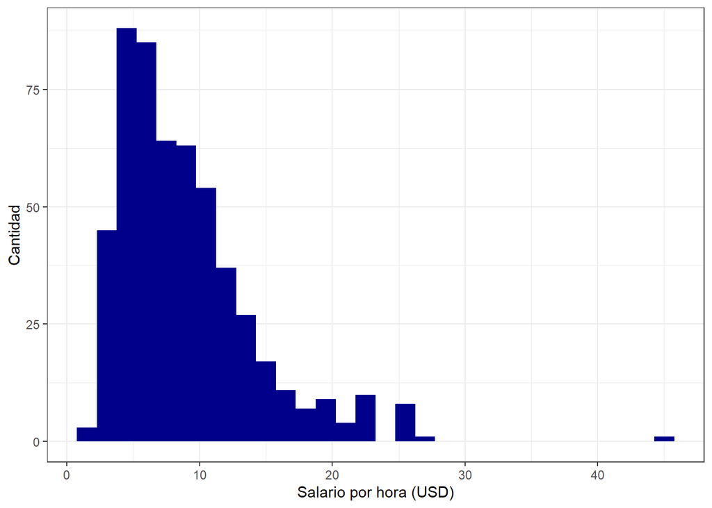

```r
ggplot(df, aes(x = wage)) +
  geom_histogram(fill = "darkblue") +
  theme_bw() +
  labs(x = "Salario por hora (USD)", y = "Cantidad")
```

Veamos como se relacionan nuestras variables continuas con el salario.

```r
library(GGally)
names(df)
```

```
##  [1] "wage"       "education"  "experience" "age"        "ethnicity"
##  [6] "region"     "gender"     "occupation" "sector"     "union"
## [11] "married"
```

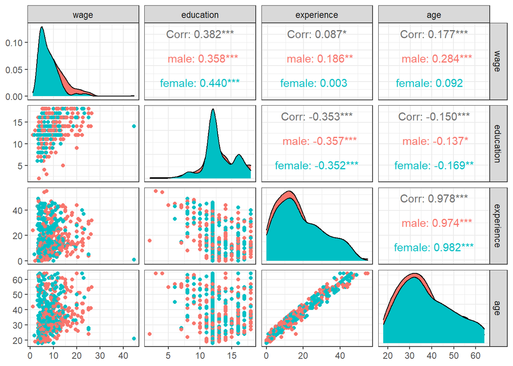

```r
ggpairs(df, columns = 1:4, ggplot2::aes(colour = gender)) +
  theme_bw()
```

De la primera gráfica se puede ver que el salario de los hombres es mayor que el de las mujeres en promedio. Adicionalmene, la primera columna parece indicar que para mismos niveles de educación, experiencia y edad, los hombres ganan más que las mujeres en promedio. No obstante, no se está controlando por las demás características observadas las cuales podrían explicar esta disparidad.

Finalmente vamos a ver la distribución de nuestras variables categóricas

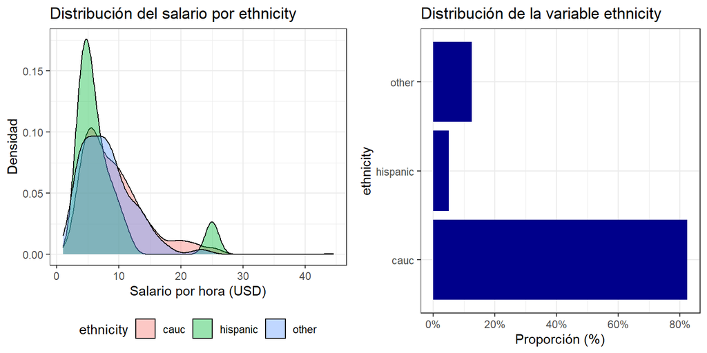

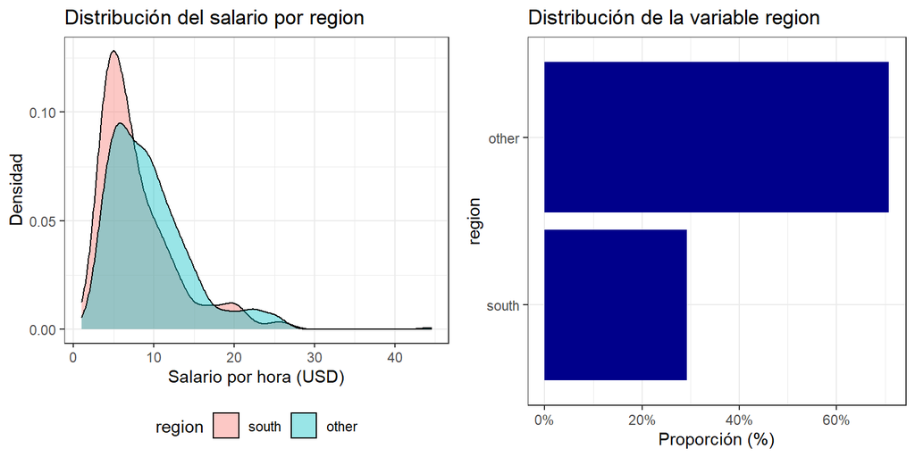

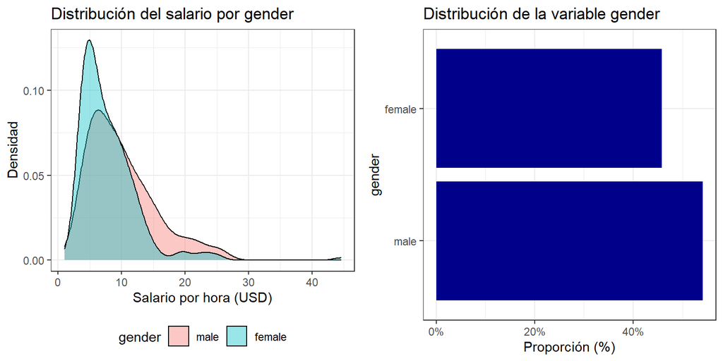

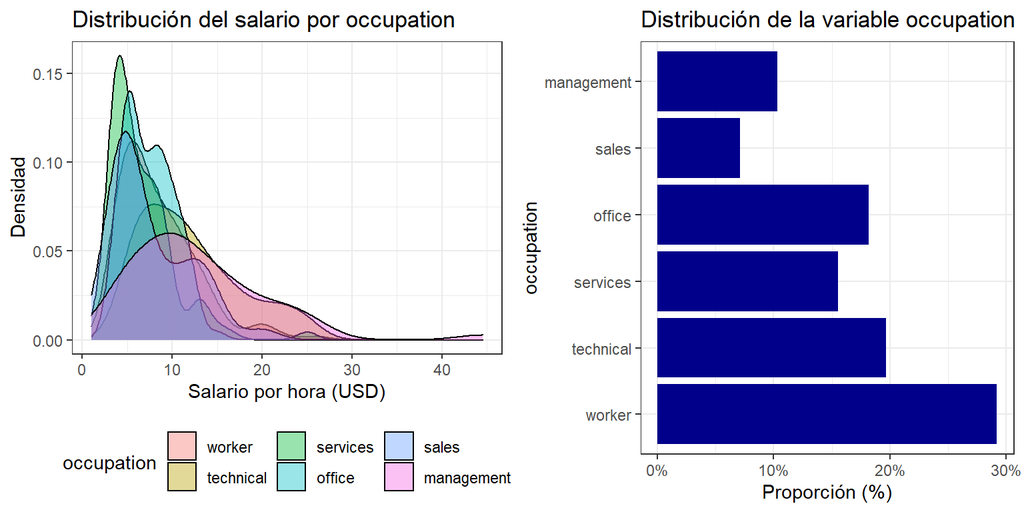

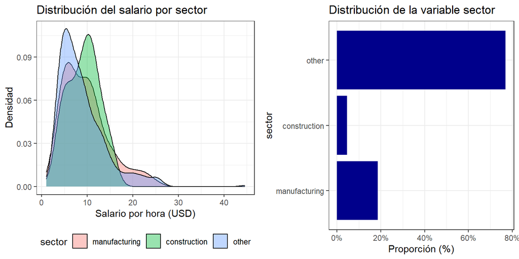

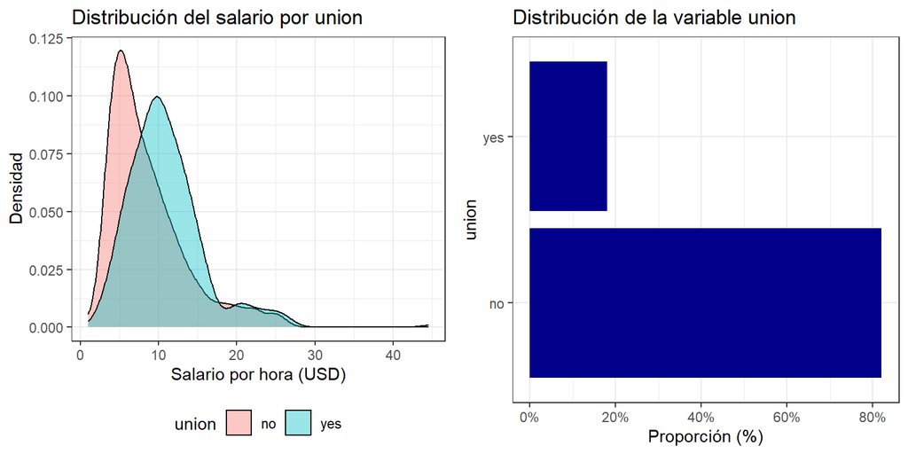

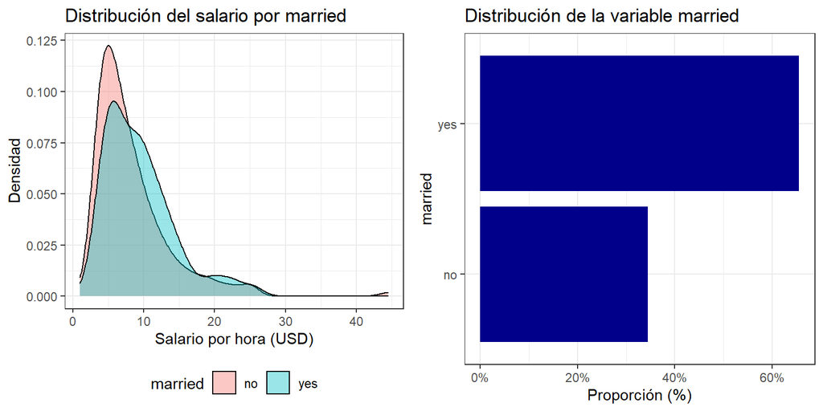

```r
library(gridExtra)
variables_categoricas <- names(df[,sapply(df, is.factor)])

for (var in variables_categoricas) {
  p1 <- ggplot(df, aes(x = wage, fill = .data[[var]])) +
    geom_density(alpha = 0.4) +
    labs(x = "Salario por hora (USD)",
         title = paste("Distribución del salario por", var),
         y = "Densidad") +
    theme_bw() +
    theme(legend.position = "bottom")

  p2 <- ggplot(df, aes(y = .data[[var]])) +
    geom_bar(aes(x = (..count..)/sum(..count..)),
             fill = "darkblue") +
    labs(title = paste("Distribución de la variable", var),
         x = "Proporción (%)") +
    scale_x_continuous(labels = scales::percent) +
    theme_bw()

  grid.arrange(p1, p2, ncol = 2)
}
```

# Modelos

```r
library(caret)
# Dividimos la base en train y test
set.seed(666)
train_index <- createDataPartition(df$wage, p = .8)$Resample1
train_df <- df[train_index,]
test <- df[-train_index,]

# Creamos las particiones para hacer validación cruzada
cv5 <- trainControl(number = 5, method = "cv")
cv3 <- trainControl(number = 3, method = "cv")
```

## Árbol de decisión

[figure not shown]

```r
# Caret ya hace una selección del mejor hiperparámetro
# cp (complexity parameter) cuando se le especifica el
# método rpart sin necesidad de incluir alguna grilla
modelo1 <- train(wage ~ .,
                 data = train_df,
                 method = "rpart",
                 trControl = cv5)

library(rattle)
fancyRpartPlot(modelo1$finalModel)
```

```r
y_hat_insample1 = predict(modelo1, newdata = train_df)
y_hat_outsample1 = predict(modelo1, newdata = test)

library(MLmetrics)
MAE(y_pred = y_hat_insample1, y_true = train_df$wage)
```

```
## [1] 3.480591
```

```r
MAPE(y_pred = y_hat_insample1, y_true = train_df$wage)
```

```
## [1] 0.4664507
```

```r
MAE(y_pred = y_hat_outsample1, y_true = test$wage)
```

```
## [1] 3.160853
```

```r
MAPE(y_pred = y_hat_outsample1, y_true = test$wage)
```

```
## [1] 0.5013568
```